# The EatConscious Package

Annie Johansson

5/26/2022

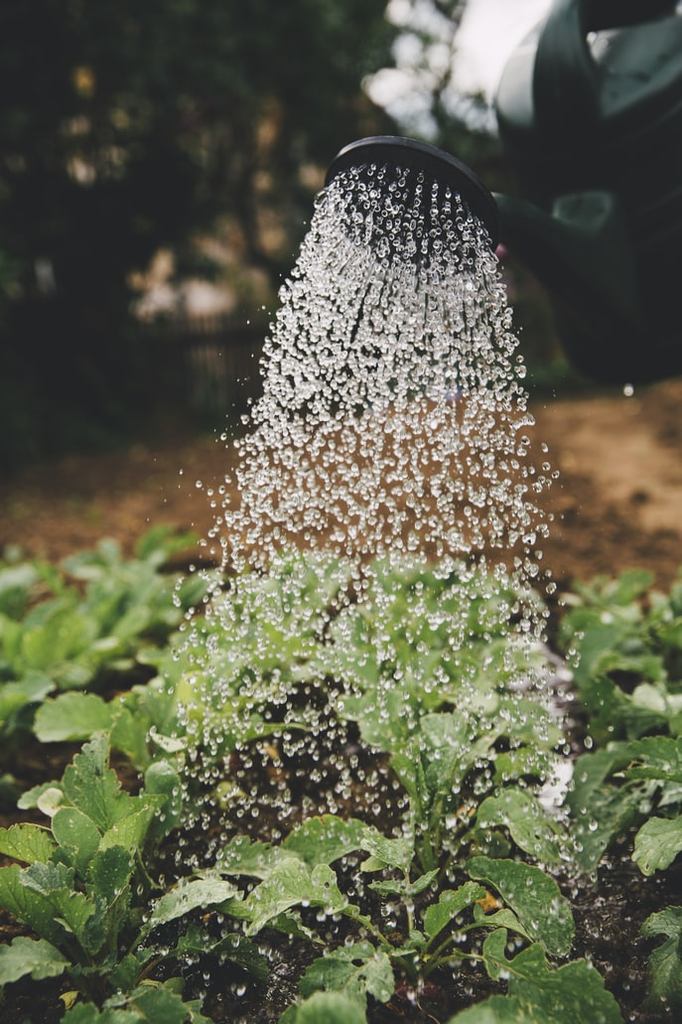

EatConscious is an r package intended to help you eat more consciously. It can retrieve and visualize nutritional and climate-impact data about most types of fresh produce.

## Water Footprint data

Over 2.7 billion people are affected by scarce water resources yearly. The water footprint metric, created by Arjen Hoekstra, is a type of environmental footprint that helps us to understand how the human consumption of different products is affecting the earth’s natural water sources. Making conscious choices about which products to consume will aid in reducing our water foot print and ultimately preserve water for people and nature.

The water footprint data used in this package comes from The Water Footprint Network (https://waterfootprint.org/en/). The dataset comprises the green, blue, and grey water footprints for a wide range of food products on a global, national, and regional scale.

#### Types of Water Footprints

| Green | Water acquired by the crop/plant directly from natural sources, such as precipitation. |
| --- | --- |
| Blue | Water that has been sourced from surface or groundwater resources. |
| Grey | The amount of freshwater that needs to be discharged into the water source to remove pollutants and meet water quality standards. |

Read more: https://waterfootprint.org/en/water-footprint/what-is-water-footprint/

## How to use the EatConscious Package

### Installing the package

```r
devtools::install_github("Programming-The-Next-Step-2022/EatConscious/EatConscious")
```

### Graphical User Interface

You can interact with the EatConscious package through a Graphical User Interface (GUI). Here, the same functions as are outlined below are wrapped into an interactive environment where you can search for food and plot the respective data.  
To access the GUI, simply run the `GUI()` function in your console.

```r
GUI()
```

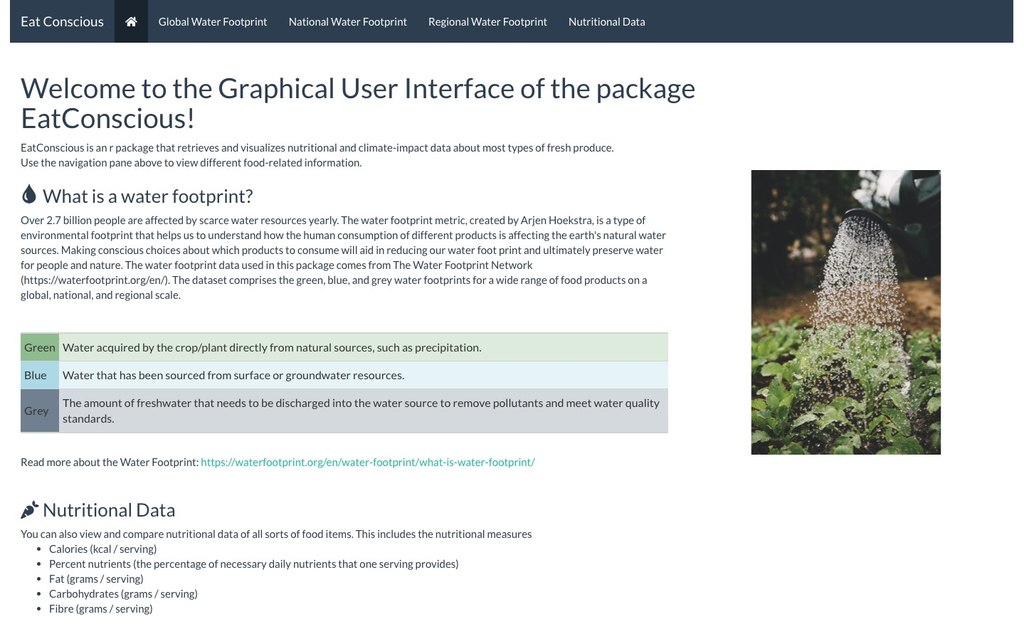

Below the functions underlying the GUI (and which can be used in your own R environment) are outlined.

## Water Footprint Functions

The water footprint functions were created using data from the Water Footprint Network. The dataset is saved within the package and is called “wf_data”.

```r
data("wf_data")

# Read more about the dataset:
?wf_data
```

#### Measures

The Water Footprint of each food item is measured as the cubic Liters of water consumed per ton of the food item produced (L<sup>3</sup>/ton).

### Retrieve and visualize global water footprint data

##### wf_global and wf_global_plot

The function `wf_global()` creates a table of water footprint data for a specific food item. Let’s say you’re interested in the global green, blue, and grey water footprint for the production of bananas:

```r
wf_global("banana")
```

```
##                                         Product WF_Type AverageWF
## 691 Bananas including plantains, fresh or dried   Green       660
## 692 Bananas including plantains, fresh or dried    Blue        97
## 693 Bananas including plantains, fresh or dried    Grey        33
```

You can plot this data with the function `wf_global_plot()`:

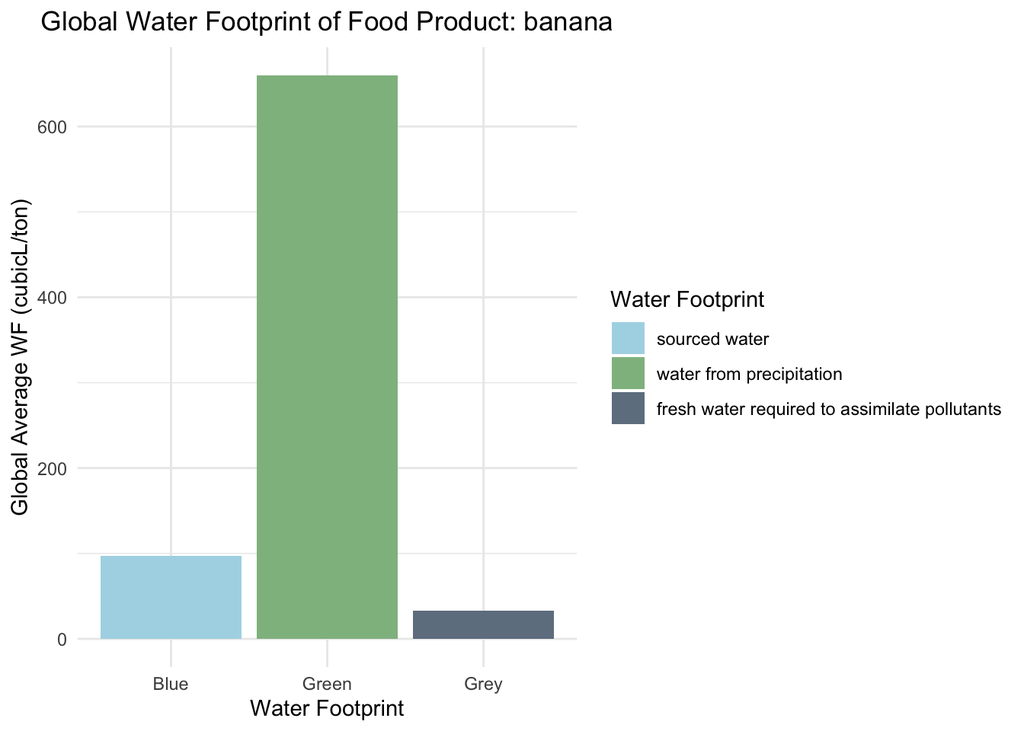

```r
wf_global_plot("banana")
```

### Retrieve and visualize national water footprint data

##### wf_country and wf_country_plot

The function `wf_country()` creates a table of water footprint data for a specific food item for a specified country.  
**Arguments:** *food* and *country*.

You should input the country name according to the FIPS country codes. You can use the `countrycodes()` function to check what country code corresponds to which country within a specified continent.

```r
head(countrycodes("Europe"))
```

```
##                 country continents code
## 2               Albania     Europe   AL
## 10              Austria     Europe   AU
## 16              Belarus     Europe   BO
## 17              Belgium     Europe   BE
## 23 Bosnia & Herzegovina     Europe   BK
## 27             Bulgaria     Europe   BU
```

```r
# Example: water footprint for wheat production in the Netherlands:
wf_country("wheat", "NL")
```

```
##                                     Product WF_Type  NL
## 7 Wheat (Durum wheat, Wheat nes and meslin)   Green 511
## 8 Wheat (Durum wheat, Wheat nes and meslin)    Blue
## 9 Wheat (Durum wheat, Wheat nes and meslin)    Grey 183
```

It might be interesting to see the water footprint of wheat production in the Netherlands compared to other countries across Europe.  
You can plot the national water footprints of all countries using the function `wf_country_plot`. This is done per continent.

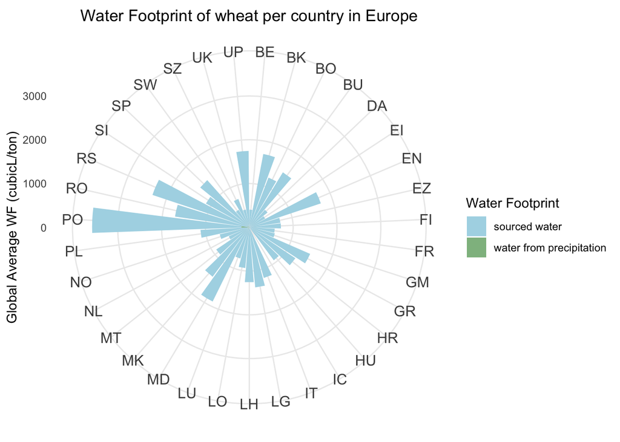

```r
wf_country_plot("wheat", "Europe")
```

*It seems like Portugal has a large water footprint for wheat production. It also seems like the water footprint of wheat production across Europe is mainly comprised of water sourced from surface or groundwater resources - interesting!*

### Retrieve and visualize regional water footprint data

##### wf_region and wf_region_plot

Some countries, such as the US, have very different climates in different regions. The `wf_region()` and `wf_region_plot()` retrieves water footprint data of a food item per region of the specified country.

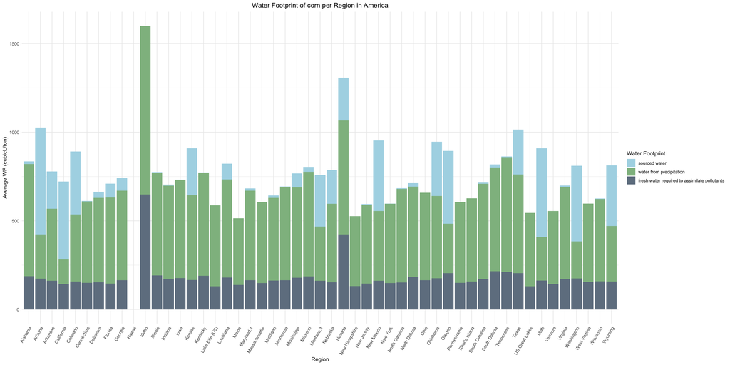

```r
wf_region_plot("corn", "America")
```

## Nutritional data

Several functions in the EatConscious package allow you to retrieve and visualize nutritional data of fresh produce items. These functions access data from the Food Database API https://www.edamam.com. With these functions you can:

- View data about nutrients, calories, carbohydrates, fat, and fibre of food items.
- Compare two different food items based on a nutritional metric.
- Plot the nutritional data of the food item.

#### Measures

- Calories, kcal / serving.
- Percent nutrients, the percentage of necessary daily nutrients that one serving provides.
- Fat, grams / serving.
- Carbohydrates, grams / serving.
- Fibre, grams / serving.

### Nutrient functions

In all nutrient functions, the food argument works as a search tool through the API to return rows of information that match closest to the search query. If you want only the first search hit, you can index the first row. ( *e.g.* `get_nutrients("kiwi", "all")[1, ]`)

#### Return a table of nutritional data

The `get_nutrients()` function returns a table of nutritional data for the specified food item. It takes two arguments, food and measure. If “all” is specified, it will return a table of all the nutritional measures for the food item.

```r
get_nutrients("tomato", "all")
```

```
##           label calories percent_nutrients  fat carbohydrates fibre
## 1        Tomato       18              0.88  0.2          3.89   1.2
## 2   Beef Tomato       18              0.88  0.2          3.89   1.2
## 3  Heart Tomato       18              0.88  0.2          3.89   1.2
## 4   Vine Tomato       18              0.88  0.2          3.89   1.2
## 5   Pear Tomato       18              0.88  0.2          3.89   1.2
## 6 Yellow Tomato       15              0.98 0.26          2.98   0.7
## 7  Green Tomato       23               1.2  0.2           5.1   1.1
## 8 Orange Tomato       16              1.16 0.19          3.18   0.9
```

```r
get_nutrients("carrot", "carbohydrates")
```

```
##                label carbohydrates
## 1            Carrots          9.58
## 2     Frozen Carrots           7.9
## 3        Baby Carrot          8.24
## 4       Carrots, Raw          9.58
## 5     Canned Carrots          5.37
## 6       Carrot Juice          9.28
## 7 Carrot, Dehydrated         79.57
## 8        Carrot Cake          79.2
```

```r
# Measure specified as "calories", "percent_nutrients", "fat", "carbohydrates", "fibre", or "all".
```

#### Plot nutritional data

The function `plot_nutrients()` returns two pie charts that display the percentage of recommended daily nutrient intake that one serving of the food item gives.

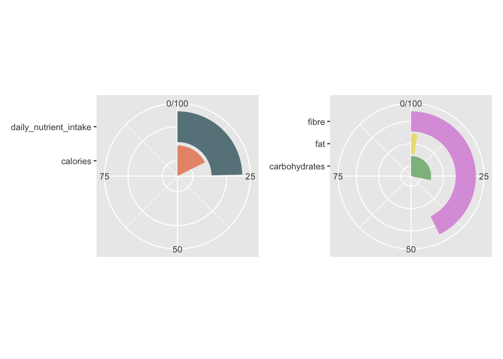

```r
plot_nutrients("lentils")
```

*Take a look at how nutritious lentils are!*

#### Compare nutritional data

The function `compare_nutrients()` returns a bar chart that plots a nutritional measure of two food items side-by-side.

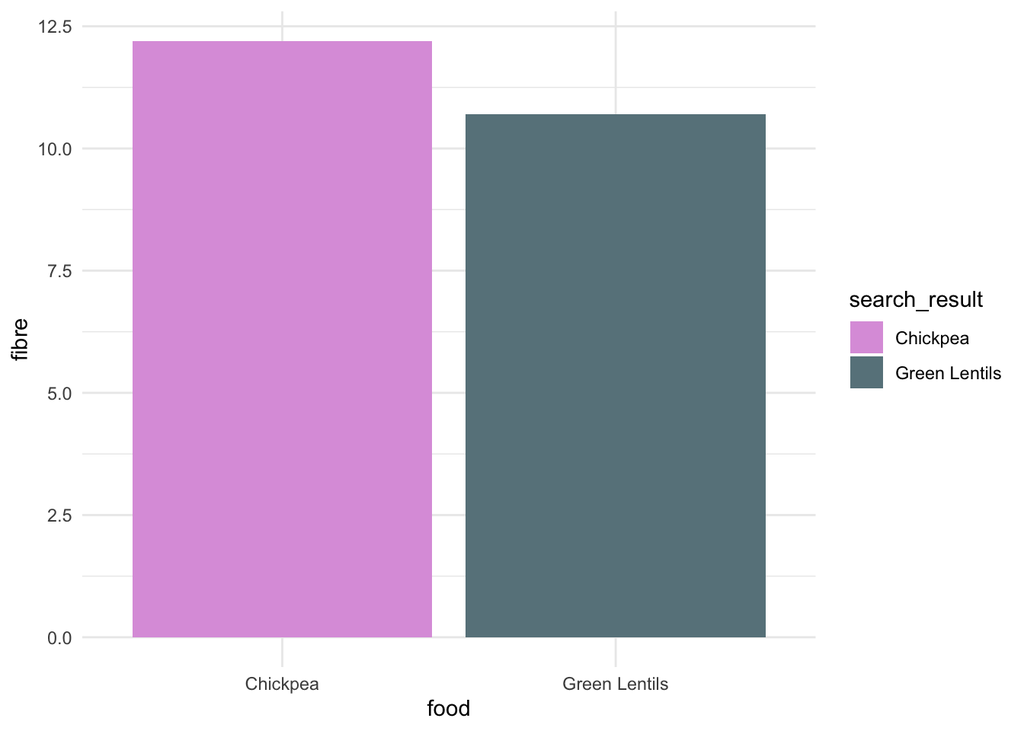

```r
compare_nutrients("lentils", "chickpeas", "fibre")
```

*It looks like chickpeas are even more rich in fibre!*

This information can also be displayed in a table with a few simple lines:

```r
lentils <- as.data.frame(get_nutrients("lentils", "fibre"))[1, ]
chickpeas <- as.data.frame(get_nutrients("chickpeas", "fibre"))[1, ]
rbind(lentils, chickpeas)
```

```
##           label fibre
## 1 Green Lentils  10.7
## 2      Chickpea  12.2
```

## Search function

To check whether the food is available in the (nutritional) database, use the `search_food()` function. This function also retrieves a picture of the food, and a summary of its water footprint and nutrient data! To mask the image, you can use the argument `picture = FALSE`.

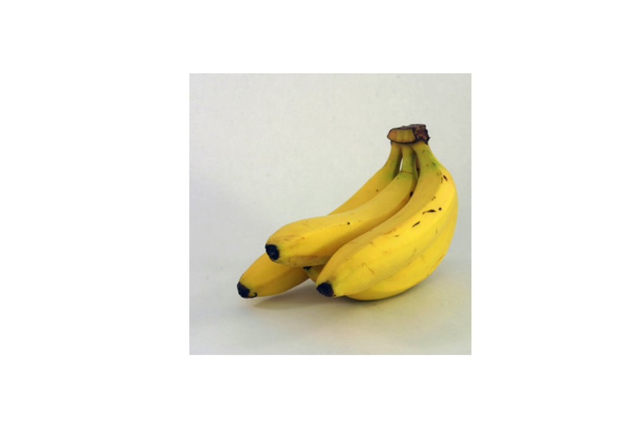

```
## $nutrients
##                           search_result calories percent_nutrients  fat
## 1                                Banana       89              1.09 0.33
## 2 Bananas, Dehydrated, or Banana Powder      346              3.89 1.81
## 3                          Bananas, Raw       89              1.09 0.33
## 4                         Banana Pepper       27              1.66 0.45
##   carbohydrates fibre
## 1         22.84   2.6
## 2         88.28   9.9
## 3         22.84   2.6
## 4          5.35   3.4
##
## $water_footprint
##                                         Product WF_Type AverageWF
## 691 Bananas including plantains, fresh or dried   Green       660
## 692 Bananas including plantains, fresh or dried    Blue        97
## 693 Bananas including plantains, fresh or dried    Grey        33
```

```r
search_food("banana")
```

Read more about all of the functions using the function help files!